# Hockey Analytics Final Project Report

Jeff Jung

Fall 2023 Nov 26th

# 1 DAR Project and Group Members

Jeff Jung Caleb Smith Liebin Zhang Ashley Woodson Amy Enyenihi

# 2 Project

Hockey Analytics

# 3 Abstract

This research project explores the application of data analytics to gain insights into the performance of the RPI women’s hockey team based on shot data. The project involves a multi-step analysis, beginning with thorough data cleaning to eliminate outliers that may skew the results. Subsequently, continuous variables such as puck distance, puck angle, and player speeds are discretized through careful categorization determined by the examination of density plots. The discretized variables are then used in the creation of cluster models using the k-means algorithm. This cluster analysis aims to unveil patterns and relationships within the data, shedding light on factors influencing successful goals or saves. By employing a systematic approach that combines data cleaning, categorization, and clustering, this project contributes to the understanding of key variables impacting the outcomes of hockey shots.

# 4 Introduction and Background

The purpose of hockey analytics is to utilize statistical analysis and advanced metrics to gain deeper insights into player and team performance, enabling data-driven decision-making in various aspects of the sport. By examining detailed statistics and metrics beyond traditional measures, hockey analytics helps teams evaluate player contributions, optimize strategic approaches, and identify areas for improvement. Ultimately, the goal is to enhance overall team performance, inform coaching decisions, and provide a more comprehensive understanding of the game.

The dataset utilized for this project was sourced from the RPI women’s hockey team and comprises a total of 105 shots. It encompasses nine continuous and five categorical variables. A more detailed explanation of the dataset will be provided in subsequent sections.

In light of limited data on goals, my research primarily concentrated on exploring datasets associated with saves. Initially, I sought to understand the central tendency and variability of saves by calculating the median and standard deviation. However, these summary statistics lacked granularity. Consequently, I turned to density plots for visualization, revealing interesting patterns in the data distribution. Notably, each variable exhibited distinct concentration ranges, prompting me to categorize continuous variables based on the observed density plot shapes.

```
## • Use tidymodels_prefer() to resolve common conflicts.
```

```
## Median of Puck Distance for Saves: 454.3136
```

```
## Standard Deviation of Puck Distance for Saves: 174.835
```

# 5 Problems Tackled

The main problem that was considered was how we can improve the analysis. One way to do that is by discretizing continuous variables, specifically puckDist, puckAngle, puckSpeed, shooterSpeed, goalieDist, goalieAngle, posTime, defDist, and defAngle. The initial step involves cleaning the data to mitigate potential skewness. Subsequently, we examine density plots using the cleaned data to identify suitable ranges for discretization. Employing the k-means method, we create two distinct sets of clusters: one for continuous variables and another for categorical variables. This process aims to enhance the granularity of our analysis and facilitate a more nuanced exploration of the dataset.

# 6 Data Description

The main dataset utilized, named “shots,” is derived from games played by the RPI women’s hockey team, comprising a total of 105 observations or shots. It encompasses nine continuous variables: puckDist, puckAngle, puckSpeed, shooterSpeed, goalieDist, goalieAngle, posTime, defDist, and defAngle. Additionally, there are five categorical variables: NumOffense, NumDefense, rightHanded, closestDef, and shotOutcome.

In the initial stage of data processing, a two-step approach to data cleaning is implemented. The process involves two functions: detect_outlier and remove_outlier. The detect_outlier function identifies all outliers in the dataset, while the remove_outlier function eliminates the data points classified as outliers by the detect_outlier function. This systematic approach ensures the removal of any anomalous or extreme values, contributing to a cleaner and more reliable dataset for subsequent analyses.

The assignment of discretized values follows a straightforward process. For instance, all puckDist values below 310 are assigned 0, and those above 310 are assigned 1. In cases where there are three categories, an additional value is assigned. For example, the categorized defenderAngle variable assigns values below 63 to 0, values between 63 and 112 to 1, and values above 112 to 2. The specific cutoffs for each feature are detailed in the “Variable Categorization Based on Quantiles” table. To ensure these variables function as discretized categories, the assigned values are converted into factors. This systematic approach enhances the interpretability and utility of the discretized variables in subsequent analyses.

Variable Categorization

| Variable | Cutoffs |
| --- | --- |
| puckDist | 310 |
| puckAngle | 90 |
| puckSpeed | 15, 50 |
| shooterSpeed | 17, 25 |
| goalieDist | 58, 80 |
| goalieAngle | 80 |
| posTime | 45 |
| defDist | 250 |
| defAngle | 63, 112 |

# 7 Data Analytics Methods

After obtaining a cleaned dataset devoid of outliers, I proceeded to exclude the original categorical variables from the shot_stats_goal data. This facilitated a focused comparison between the newly created categorical variables and their corresponding continuous counterparts. Employing the k-means machine learning algorithm, I developed two models—one for the original data and another for the categorical data. To ensure optimal cluster identification, an elbow test was conducted. Despite this, I chose to utilize 5 clusters to align with Caleb’s cluster data, given the inherent variability in cluster assignments by the k-means algorithm. The resulting models were saved as files for future reference.

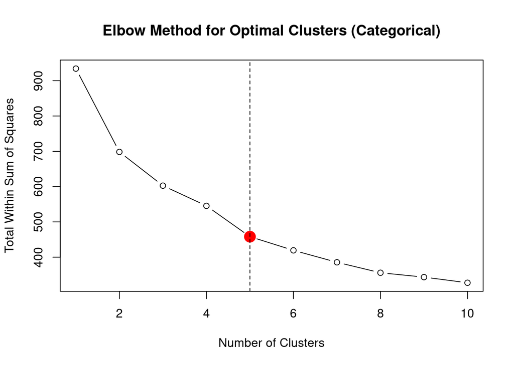

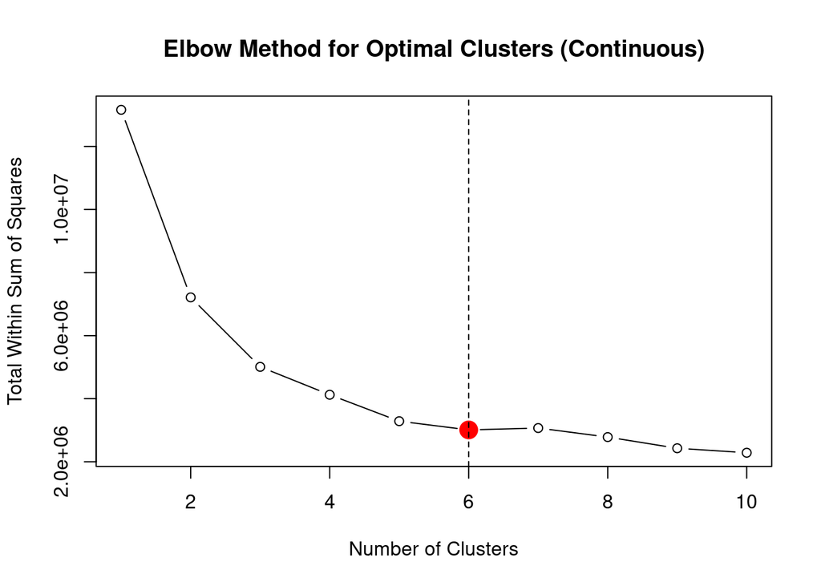

# 8 Experimental Results

Utilizing the original and categorical clusters derived from the preceding analyses, a heatmap was generated by constructing a correlation matrix between these two groups of clusters. The heatmap visually represents the degree of correlation between pairs of variables, employing a numeric scale reflected in the color intensity within each cell. Larger numerical values indicate a higher correlation, while smaller values signify a lower correlation. This visual representation facilitates the interpretation of relationships and associations between variables within the context of both original and categorical cluster groupings.

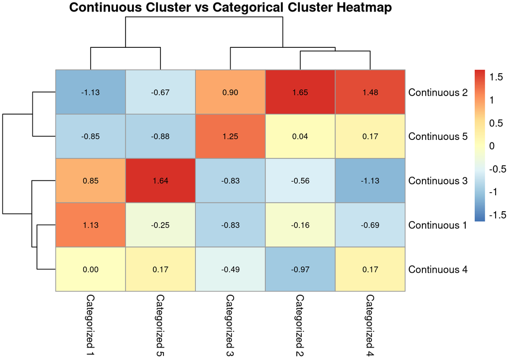

Furthermore, I generated heatmaps by constructing correlation matrices between each outcome and the two groups of clusters. These visualizations aim to illuminate the likelihood of specific outcomes associated with each cluster. This classification approach provides insights into the characteristics and patterns associated with different clusters, offering a comprehensive understanding of the potential outcomes and their correlations with specific shot attributes.

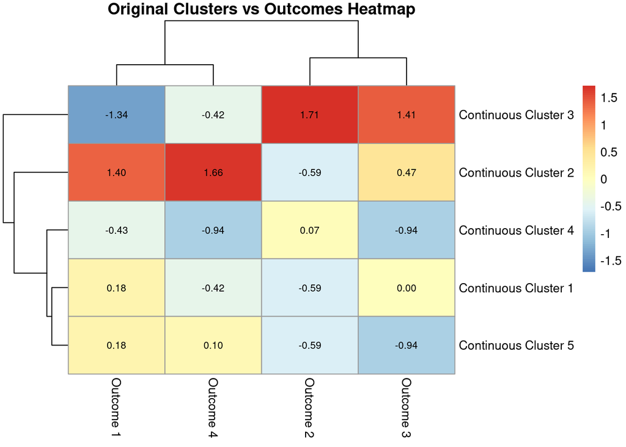

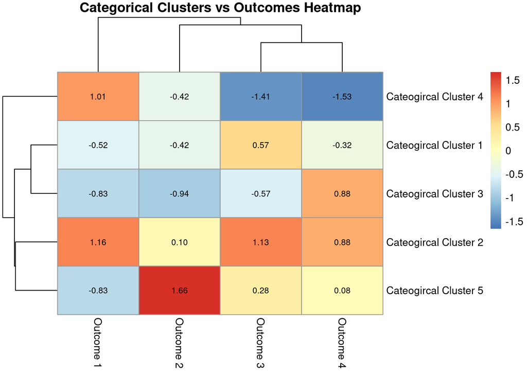

For each cluster for discretized data, the mode discrete value for each feature is shown in the “Discrete Mode Values” table.

Discrete Model Values

| cat_cluster | outcomes.goal | puckSpeedCategory | puckAngleCategory | puckDistCategory | posTimeCategory | goalieDistCategory | shooterSpeedCategory | goalieAngleCategory | defDistCategory | defAngleCategory |
| --- | --- | --- | --- | --- | --- | --- | --- | --- | --- | --- |
| 1 | 3 | 3 | 1 | 2 | 2 | 2 | 2 | 1 | 1 | 3 |
| 2 | 3 | 2 | 1 | 2 | 1 | 2 | 1 | 1 | 1 | 3 |
| 3 | 3 | 2 | 2 | 2 | 1 | 3 | 1 | 2 | 2 | 1 |
| 4 | 1 | 2 | 2 | 2 | 1 | 2 | 1 | 2 | 1 | 1 |
| 5 | 3 | 2 | 2 | 1 | 1 | 1 | 1 | 2 | 1 | 1 |

Describing the characteristics of each cluster for continuous variables provides insights into distinct shot patterns. Shots in Cluster 1 are taken from a considerable distance from the goal, exhibiting high puck speed and possession time, indicating long and calculated shots. Cluster 2 comprises shots taken from an exceptionally far distance with a slow pace. Shots in Cluster 3 are characterized by intense pressure from the goalie and defenders. Cluster 4 represents mid-range shots with a moderate puck speed. Finally, shots in Cluster 5 are exceptionally far and fast, suggesting shots with both considerable distance and speed.

For each cluster for continuous data, the mean value for each feature is shown in “Continuous Mean Values” table.

Continuous Mean Values

| Group.1 | puckDist | puckAngle | puckSpeed | shooterSpeed | goalieDist | goalieAngle | posTime | defDist | defAngle |
| --- | --- | --- | --- | --- | --- | --- | --- | --- | --- |
| 1 | 429.0734 | 85.08309 | 43.24438 | 18.63413 | 74.60591 | 78.96551 | 42.78947 | 120.64397 | 116.34889 |
| 2 | 577.3543 | 82.26851 | 38.55734 | 12.54376 | 83.53557 | 75.38863 | 30.60714 | 161.56247 | 94.38426 |
| 3 | 147.5481 | 77.51730 | 38.48058 | 17.18447 | 45.33600 | 63.08071 | 20.66667 | 94.58971 | 102.01265 |
| 4 | 290.6015 | 98.85316 | 42.68814 | 18.39713 | 65.12851 | 96.68207 | 27.18750 | 159.86220 | 87.33023 |
| 5 | 549.3437 | 90.63352 | 47.81298 | 14.04467 | 75.97900 | 80.39762 | 25.44444 | 446.61064 | 92.61817 |

Describing the characteristics of each cluster for discretized variables reveals distinct patterns. Shots in Cluster 1 are characterized by a fast puck speed, a long possession time, and a rapid shooter speed. Cluster 2 encompasses mid-range shots with moderate speed, resembling Cluster 4, but predominantly taken from the right side. Shots in Cluster 3 are notable for being taken from a considerable distance from the goal and defender. Cluster 4 shares similarities with shots in Cluster 2 but is predominantly taken from the left side. Finally, shots in Cluster 5 represent high-pressure situations, taken in close proximity to the goalie and defender.

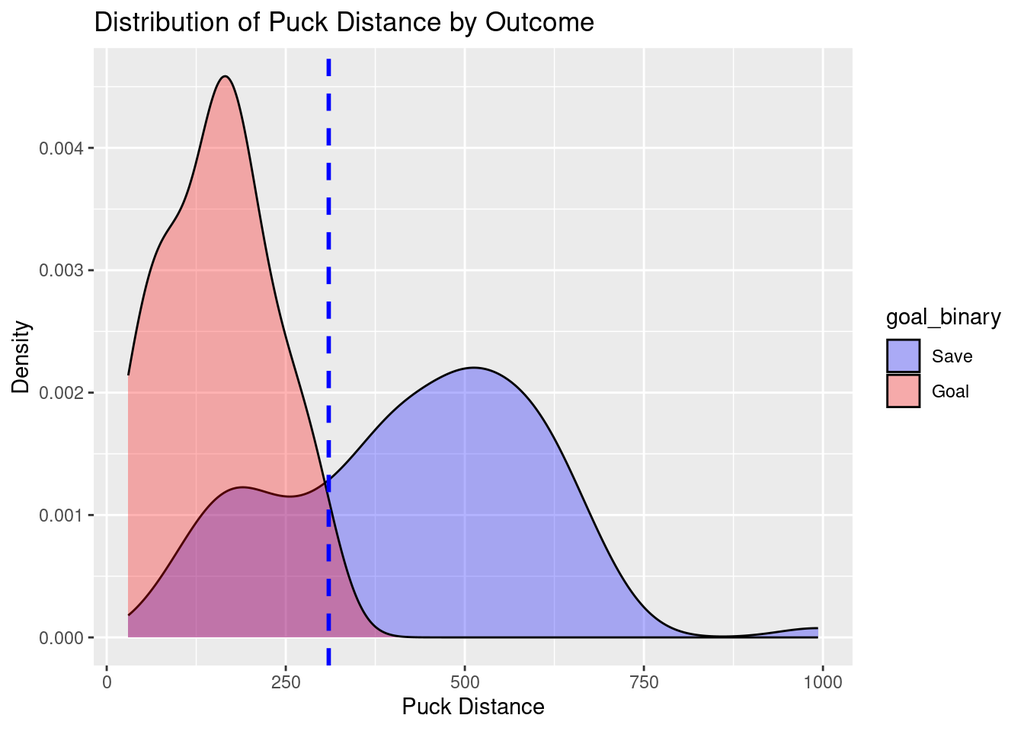

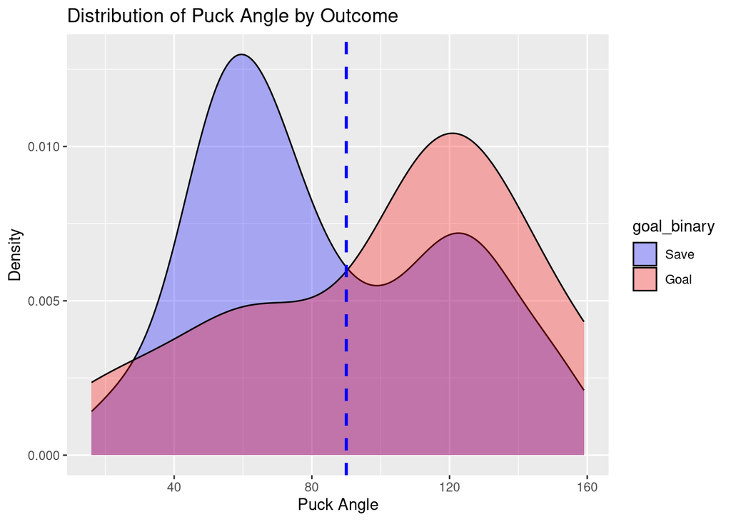

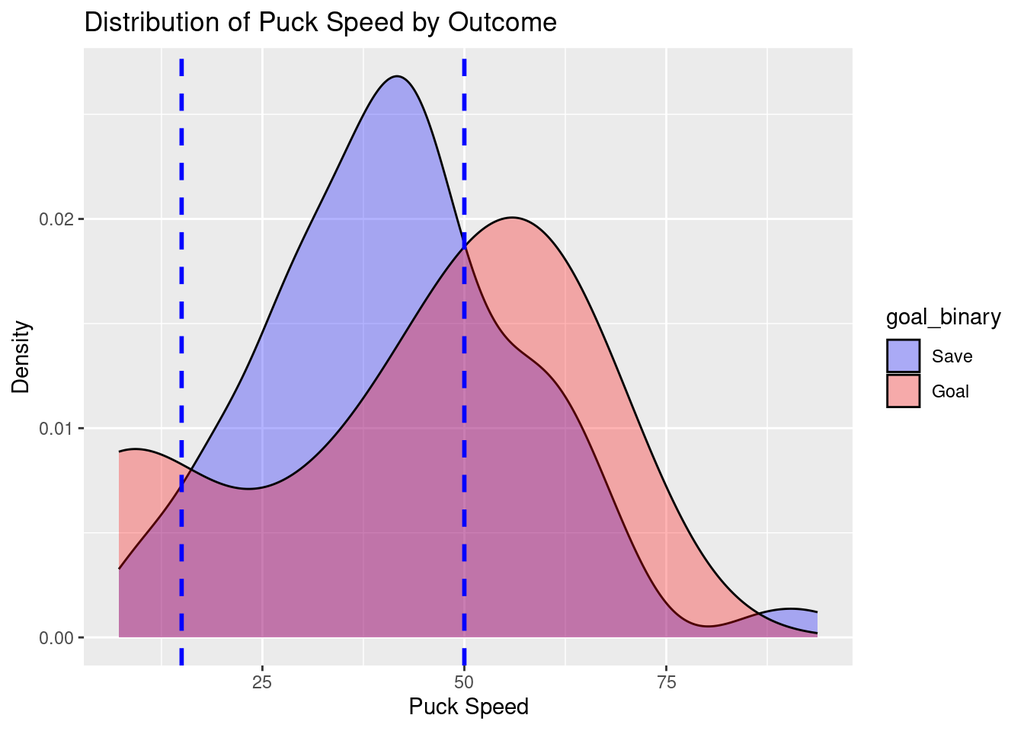

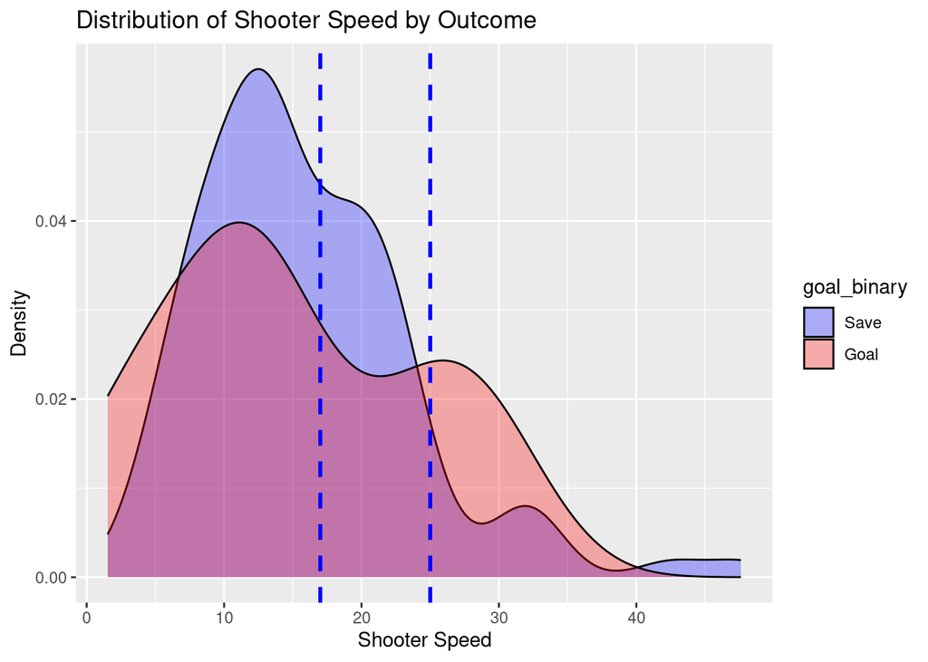

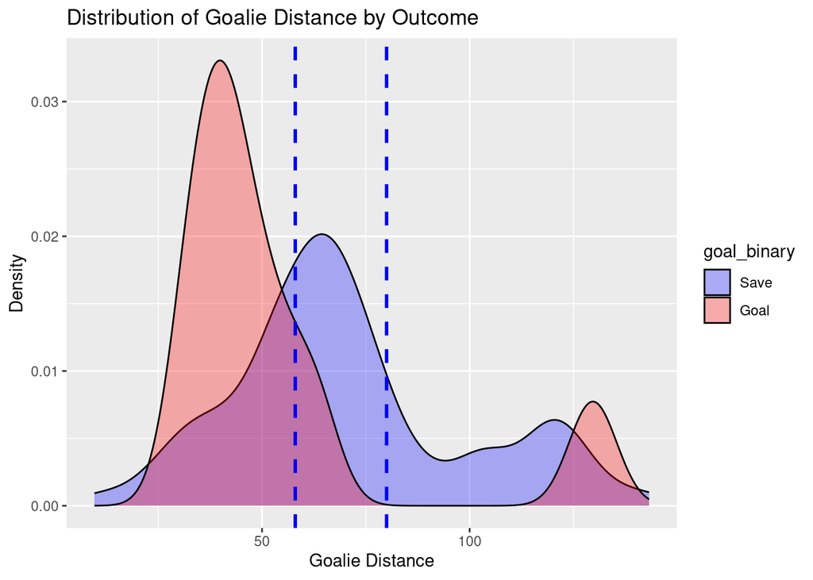

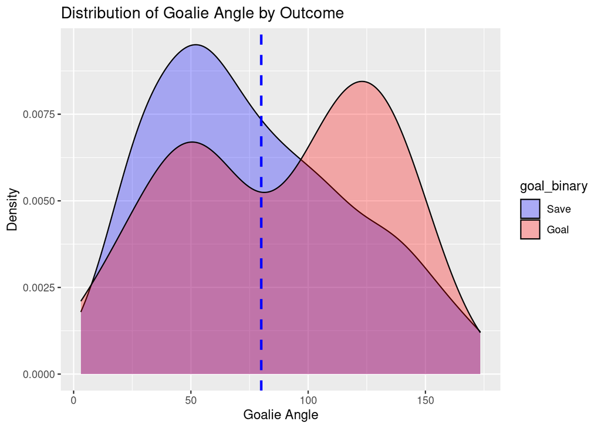

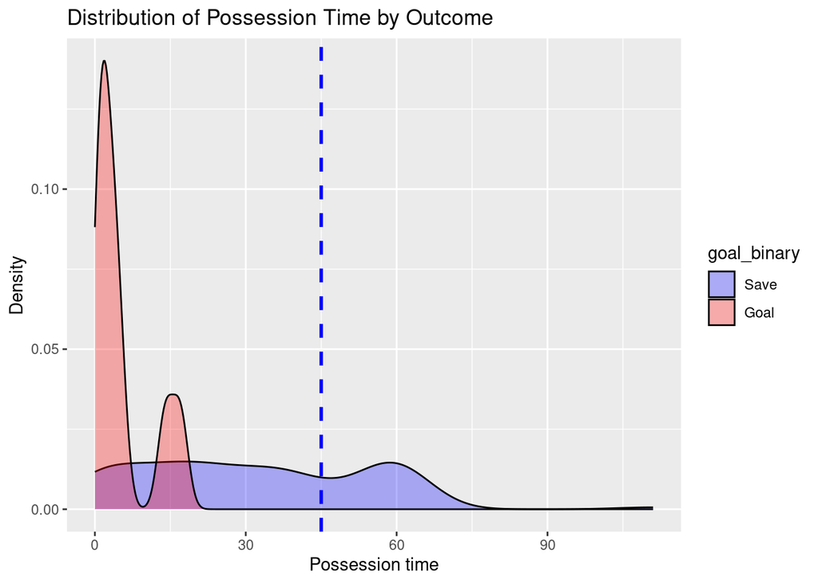

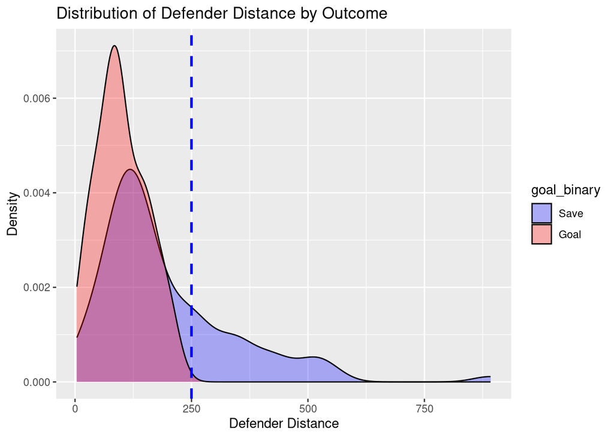

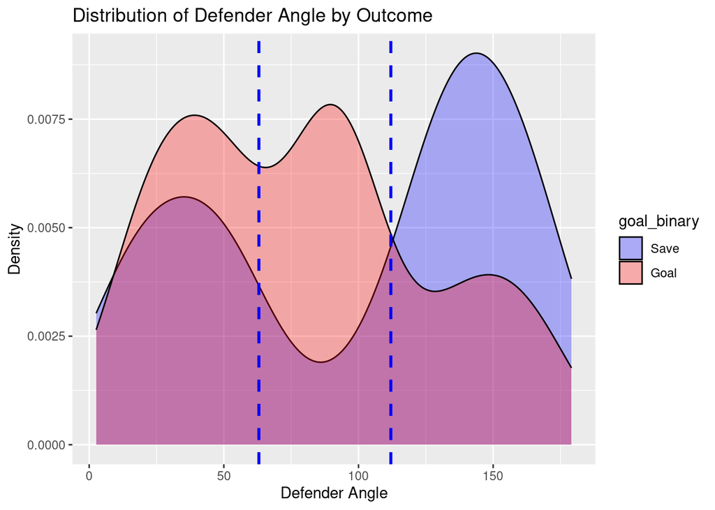

Lastly, the density plots above were used to find the cutoffs for discretization. Marks were added where the cutoffs are.

# 9 Discussion of Results and Key Findings

The insights gained from this analysis hold significant implications for hockey strategy. By delving into shot clusters using categorical variables, players can derive optimal shot combinations tailored to specific game scenarios. This analytical approach not only answers nuanced questions but also unveils patterns that may remain obscure without data-driven exploration. For instance, it allows us to determine the ideal goalie angle category when facing a shot with a considerable puckDist. This knowledge empowers players and teams to make informed decisions, enhancing their strategic prowess on the ice.

# 10 Conclusions

The distinctive patterns observed in these clusters underscore their meaningful nature, dismissing the notion of mere chance. This clustering aligns with the prevalent trends in shot-taking scenarios. The application of hockey data analytics promises to revolutionize our comprehension of the sport, unveiling insights that are uniquely attainable through analytical methodologies. The process of data discretization proves pivotal in this context, as categorical variables offer a nuanced understanding beyond singular numerical values. By adopting a more scientific approach to shot selection, informed by the concealed insights within the data, hockey players and teams can elevate their strategic decision-making on the ice.

# 11 Directions for Future Investigation

With an increased volume of data, we can enhance categorization methodologies, possibly identifying additional clusters that capture diverse shot scenarios. The primary objective remains the same – to discern the optimal shot selection in situations where making a shot is imperative. This iterative process, fueled by more extensive data, promises to unveil deeper insights into the nuanced dynamics of hockey shots, contributing to a more comprehensive understanding of strategic decision-making in the sport.

# 12 Bibliography

http://www.sthda.com/english/wiki/saving-data-into-r-data-format-rds-and-rdata#google_vignette https://stackoverflow.com/questions/32684931/how-to-aggregate-data-in-r-with-mode-most-common-value-for-each-row

# 13 Files and Github Commits

Uploaded the final project notebook to FinalReport folder.

# 14 Contribution

Density plots other group mates to better understand the data set. The data set with categorized variables helped other group members to experiment with analytical methods.